# Summary of PICRUSt2 analysis of the PET plastisphere

```python
import os
import pandas as pd
import csv
import numpy as np
import math
from matplotlib.lines import Line2D
import matplotlib as mpl
from matplotlib.patches import Patch
import matplotlib.pyplot as plt
import random
from scipy.spatial import distance
from scipy import stats
from sklearn import manifold
from sklearn.decomposition import PCA
import statsmodels.stats.multitest as sm
from mpl_toolkits.axes_grid1 import make_axes_locatable

def get_cols(num):
    colormap_20, colormap_40b, colormap_40c = mpl.cm.get_cmap('tab20', 256), mpl.cm.get_cmap('tab20b', 256), mpl.cm.get_cmap('tab20c', 256)
    norm, norm2 = mpl.colors.Normalize(vmin=0, vmax=19), mpl.colors.Normalize(vmin=20, vmax=39)
    m1, m2, m3 = mpl.cm.ScalarMappable(norm=norm, cmap=colormap_20), mpl.cm.ScalarMappable(norm=norm, cmap=colormap_40b), mpl.cm.ScalarMappable(norm=norm2, cmap=colormap_40c)
    colors_20 = [m1.to_rgba(a) for a in range(20)]
    colors_40 = [m2.to_rgba(a) for a in range(20)]+[m3.to_rgba(a) for a in range(20,40)]
    if num < 21: return colors_20
    elif num < 41: return colors_40
    else: return colors_40+colors_40+colors_40
```

Here I have several sections showing an exploration of genes for PET degradation present in the PICRUSt2 predicted metagenomes.

## Summary

### Genes included

Summary of the genes that we are looking for in the predicted metagenomes.

```python
cols = ['KEGG ortholog', 'Product', 'Added to PICRUSt2']
genes = [['K21104', 'Poly(ethylene terephthalate) hydrolase (PETase)', 'HMM'], ['K18074', 'Terephthalate 1,2-dioxygenase oxygenase component (alpha subunit; tphA2)', 'HMM'], ['K18074', 'Terephthalate 1,2-dioxygenase oxygenase component (alpha subunit; tphA3)', 'HMM'], ['K18076', '1,2-dihydroxy-3,5-cyclohexadiene-1,4-dicarboxylate dehydrogenase (tphB)', 'HMM'], ['K00448', 'Protocatechuate 3,4-dioxygenase (alpha subunit; pcaG)', 'Default'], ['K00449', 'Protocatechuate 3,4- dioxygenase (beta subunit; pcaH)', 'Default'], ['K01857', '3-carboxy-cis,cis-muconate cycloisomerase (pcaB)', 'Default'], ['K01607', '4-carboxymuconolactone decarboxylase (pcaC)', 'Default'], ['K14727', '3-oxoadipate enol-lactonase / 4-carboxymuconolactone decarboxylase (pcaL)', 'Default'], ['K01055', '3-oxoadipate enol-lactonase (pcaD)', 'Default'], ['K01031', '3-oxoadipate CoA-transferase (alpha subunit; pcaI)', 'Default'], ['K01032', '3-oxoadipate CoA-transferase (beta subunit; pcaJ)', 'Default']]
genes_df = pd.DataFrame(genes, columns=cols)
#genes_df = genes_df.set_index('KEGG ortholog')
```

```r
py$genes_df %>%
  kable() %>%
  kable_styling()
```

| KEGG ortholog | Product | Added to PICRUSt2 |
| --- | --- | --- |
| K21104 | Poly(ethylene terephthalate) hydrolase (PETase) | HMM |
| K18074 | Terephthalate 1,2-dioxygenase oxygenase component (alpha subunit; tphA2) | HMM |
| K18074 | Terephthalate 1,2-dioxygenase oxygenase component (alpha subunit; tphA3) | HMM |
| K18076 | 1,2-dihydroxy-3,5-cyclohexadiene-1,4-dicarboxylate dehydrogenase (tphB) | HMM |
| K00448 | Protocatechuate 3,4-dioxygenase (alpha subunit; pcaG) | Default |
| K00449 | Protocatechuate 3,4- dioxygenase (beta subunit; pcaH) | Default |
| K01857 | 3-carboxy-cis,cis-muconate cycloisomerase (pcaB) | Default |
| K01607 | 4-carboxymuconolactone decarboxylase (pcaC) | Default |
| K14727 | 3-oxoadipate enol-lactonase / 4-carboxymuconolactone decarboxylase (pcaL) | Default |
| K01055 | 3-oxoadipate enol-lactonase (pcaD) | Default |
| K01031 | 3-oxoadipate CoA-transferase (alpha subunit; pcaI) | Default |
| K01032 | 3-oxoadipate CoA-transferase (beta subunit; pcaJ) | Default |

```python
genes_df = genes_df.set_index('KEGG ortholog')
```

### PETases predicted

```python
petases = pd.read_csv('/Users/robynwright/Documents/OneDrive/Github/PET-plastisphere-community/PICRUSt2/results/picrust_not_reduced/ko_PETases.csv', header=None, index_col=0)
#print(petases.loc['ASV000020', :].values[0])
asvs = list(petases.index.values)
copies = list(petases.loc[:, 1])

abun = pd.read_csv('/Users/robynwright/Documents/OneDrive/PhD_Plastic_Oceans/Experiments/PET_MiSeq2/basic/Treatment1_All_percent.csv', index_col=0, header=0)

taxonomy = pd.read_csv('/Users/robynwright/Documents/OneDrive/PhD_Plastic_Oceans/Experiments/PET_MiSeq2/basic/Taxonomy.csv', header=0, index_col=0)
taxonomy = taxonomy.loc[asvs, :]
labels = ['Kingdom', 'Phylum', 'Class', 'Order', 'Family', 'Genus', 'Species']
maxs, maxs_trt = [], []
for asv in asvs:
  this_asv = taxonomy.loc[asv, :].values
  for b in range(len(this_asv)):
    if not isinstance(this_asv[b], str):
      if b == 6 and 'Unclassified' not in this_asv[b-1]:
        new = this_asv[b-1]+' sp.'
      elif 'Unclassified' not in this_asv[b-1]:
        new = 'Unclassified '+this_asv[b-1]
      else:
        new = this_asv[b-1]
      taxonomy.loc[asv, labels[b]] = new
    elif b == 6 and isinstance(this_asv[b], str):
      taxonomy.loc[asv, labels[b]] = this_asb[b-1]+' '+this_asv[b]
  maximum = abun.loc[asv, :].max(axis=0)
  maximum_id = abun.loc[asv, :].idxmax(axis=1)
  maxs.append(maximum), maxs_trt.append(maximum_id)
```

```python
taxonomy.drop(['Kingdom', 'Phylum', 'Class', 'Order', 'Family', 'Genus'], axis=1, inplace=True)
taxonomy['PETase copies'] = copies
taxonomy['Maximum relative abundance (%)'] = maxs
taxonomy['Treatment'] = maxs_trt
#taxonomy = taxonomy.sort_values(['Class', 'Order', 'Family', 'Genus', 'Species'])
taxonomy = taxonomy.sort_values(['Maximum relative abundance (%)'], ascending=False)
```

```r
py$taxonomy %>%
  kable() %>%
  kable_styling()
```

|  | Species | PETase copies | Maximum relative abundance (%) | Treatment |
| --- | --- | --- | --- | --- |
| ASV000020 | Pseudomonas sp. | 2 | 12.4684821 | Day42PET2 |
| ASV000043 | Azomonas sp. | 2 | 4.3419379 | Day14WeatherPET1 |
| ASV000098 | Unclassified Gammaproteobacteria | 2 | 1.1860303 | Day14WeatherPET1 |
| ASV000272 | Pseudomonas sp. | 2 | 0.8623088 | Day42WeatherPET2 |
| ASV000126 | Azomonas sp. | 2 | 0.5006771 | Day14WeatherPET1 |
| ASV000610 | Unclassified Rhodobacteraceae | 1 | 0.0762311 | Inoc4 |
| ASV000486 | Unclassified Pseudonocardiaceae | 2 | 0.0731886 | Day21WeatherPET3 |
| ASV000859 | Azomonas sp. | 2 | 0.0575374 | Day30WeatherPET1 |
| ASV000621 | Unclassified Pseudomonadaceae | 2 | 0.0533508 | Day14WeatherPET1 |
| ASV002089 | Marinobacter sp. | 2 | 0.0508259 | Day07PET1 |
| ASV001854 | Azomonas sp. | 2 | 0.0504286 | Day42PET2 |
| ASV002886 | Azomonas sp. | 2 | 0.0460299 | Day30WeatherPET1 |
| ASV002319 | Azomonas sp. | 2 | 0.0386274 | Day21WeatherPET1 |
| ASV002444 | Unclassified Rhodobacteraceae | 1 | 0.0376967 | Inoc3 |
| ASV008863 | Unclassified Gammaproteobacteria | 2 | 0.0365943 | Day21WeatherPET3 |
| ASV008860 | Unclassified Pseudomonadaceae | 2 | 0.0365943 | Day21WeatherPET3 |
| ASV009408 | Unclassified Gammaproteobacteria | 2 | 0.0363901 | Day30PET3 |
| ASV001422 | Azomonas sp. | 2 | 0.0359567 | Day30WeatherPET3 |
| ASV005194 | Azomonas sp. | 2 | 0.0345224 | Day30WeatherPET1 |
| ASV006460 | Spongiispira sp. | 1 | 0.0333556 | Inoc1 |
| ASV001694 | Unclassified Rhodobacteraceae | 1 | 0.0333556 | Inoc1 |
| ASV001672 | Unclassified Pseudomonadaceae | 2 | 0.0291015 | Day07WeatherPET3 |
| ASV005178 | Unclassified Gammaproteobacteria | 2 | 0.0288226 | Day30PET1 |
| ASV001181 | Unclassified Pseudonocardiaceae | 2 | 0.0288226 | Day30PET1 |
| ASV006452 | Parvibaculum sp. | 2 | 0.0285103 | Day21PET2 |
| ASV002594 | Azomonas sp. | 2 | 0.0278164 | Day42WeatherPET2 |
| ASV003071 | Azomonas sp. | 2 | 0.0257715 | Day42WeatherPET3 |
| ASV005905 | Unclassified Gammaproteobacteria | 2 | 0.0257715 | Day42WeatherPET3 |
| ASV005761 | Unclassified Pseudomonadaceae | 2 | 0.0252143 | Day42PET2 |
| ASV005789 | Unclassified Pseudomonadaceae | 2 | 0.0252143 | Day42PET2 |

[output cut: 126 more lines]

```python
sample_order = ['Day00Inoc', 'Day01NoC', 'Day03NoC', 'Day07NoC', 'Day14NoC', 'Day21NoC', 'Day30NoC', 'Day42NoC', 'Day01LowCrysWater', 'Day03LowCrysWater', 'Day07LowCrysWater', 'Day14LowCrysWater', 'Day21LowCrysWater', 'Day30LowCrysWater', 'Day42LowCrysWater', 'Day01LowCrys', 'Day03LowCrys', 'Day07LowCrys', 'Day14LowCrys', 'Day21LowCrys', 'Day30LowCrys', 'Day42LowCrys', 'Day01PET', 'Day03PET', 'Day07PET', 'Day14PET', 'Day21PET', 'Day30PET', 'Day42PET', 'Day01WeatherPET', 'Day03WeatherPET', 'Day07WeatherPET', 'Day14WeatherPET', 'Day21WeatherPET', 'Day30WeatherPET', 'Day42WeatherPET', 'Day01BHET', 'Day03BHET', 'Day07BHET', 'Day14BHET', 'Day21BHET', 'Day30BHET', 'Day42BHET']
functions_keeping = ['PETase', 'tphA2', 'tphA3', 'tphB', 'K00448', 'K00449', 'K01857', 'K01607', 'K14727', 'K01055', 'K01031', 'K01032']
colors = ['k', 'y', 'r', 'm', 'b', 'g', 'orange']
labels = ['Inoculum', 'No carbon', 'Amorphous PET\nplanktonic', 'Amorphous PET\nbiofilm', 'PET powder', 'Weathered PET powder', 'BHET']
trts = ['Inoc', 'NoC', 'LowCrysWater', 'LowCrys', 'PET', 'WeatherPET', 'BHET']

picrust_unstrat = pd.read_csv('/Users/robynwright/Documents/OneDrive/Github/PET-plastisphere-community/PICRUSt2/results/picrust_not_reduced/ko_all_metagenome_out/pred_metagenome_unstrat.tsv', index_col=0, header=0, sep='\t')
picrust_unstrat_all = pd.DataFrame(picrust_unstrat)
picrust_unstrat = picrust_unstrat.loc[functions_keeping, :]
cols = list(picrust_unstrat.columns)
rename = {}
dropping = []
for col in cols:
  for sam in sample_order:
    if sam == col[:-1]:
      rename[col] = sam
    elif 'Inoc' in col:
      rename[col] = 'Day00Inoc'
  if 'Control' in col:
    dropping.append(col)
picrust_unstrat = picrust_unstrat.rename(columns=rename)
picrust_unstrat = picrust_unstrat.drop(dropping, axis=1).loc[:, sample_order]
```

```python
handles = []
x = [0, 2, 3, 4, 5, 6, 7, 8, 10, 11, 12, 13, 14, 15, 16, 18, 19, 20, 21, 22, 23, 24, 26, 27, 28, 29, 30, 31, 32, 34, 35, 36, 37, 38, 39, 40, 42, 43, 44, 45, 46, 47, 48]
alpha = [1, 0.9, 0.8, 0.7, 0.6, 0.5, 0.4, 0.3, 0.9, 0.8, 0.7, 0.6, 0.5, 0.4, 0.3, 0.9, 0.8, 0.7, 0.6, 0.5, 0.4, 0.3, 0.9, 0.8, 0.7, 0.6, 0.5, 0.4, 0.3, 0.9, 0.8, 0.7, 0.6, 0.5, 0.4, 0.3, 0.9, 0.8, 0.7, 0.6, 0.5, 0.4, 0.3]
for c in range(len(colors)):
  handles.append(Patch(facecolor=colors[c], edgecolor='k', label=labels[c]))
day, alph = ['Inoculum', 'Day 1', 'Day 3', 'Day 7', 'Day 14', 'Day 21', 'Day 30', 'Day 42'], [1, 0.9, 0.8, 0.7, 0.6, 0.5, 0.4, 0.3]
handles.append(Patch(facecolor='w', edgecolor='w', label=''))
for d in range(len(day)):
  handles.append(Patch(facecolor='k', edgecolor='k', label=day[d], alpha=alph[d]))
def plot_picrust_raw(function):
  plt.figure(figsize=(10,4))
  ax1 = plt.subplot(121)
  ax2 = plt.subplot(122)
  count = 0
  for sample in sample_order:
    mean = picrust_unstrat.loc[function, sample].mean()
    std = picrust_unstrat.loc[function, sample].std()
    for a in range(len(trts)):
      if trts[a] in sample:
        if 'Water' in sample and 'Water' not in trts[a]:
          continue
        color, label = colors[a], labels[a]
    ax1.bar(x[count], mean, yerr=std, color=color, edgecolor='k', alpha=alpha[count], capsize=1)
    ax2.bar(x[count], mean, yerr=std, color=color, edgecolor='k', alpha=alpha[count], capsize=1)
    count += 1
  ax2.legend(handles=handles, loc='upper left', bbox_to_anchor=(1,1), fontsize=8)
  ax1.set_title(function), ax2.set_title(function)
  ax2.semilogy()
  ax1.set_ylabel('Proportion of population (%)')
  plt.sca(ax1)
  plt.ylim(ymin=0)
  plt.tight_layout()
```

## Raw PICRUSt2 abundance plots

For each of these, the left and right plots are identical but the right plot is plotted on a log scale.

### PETase

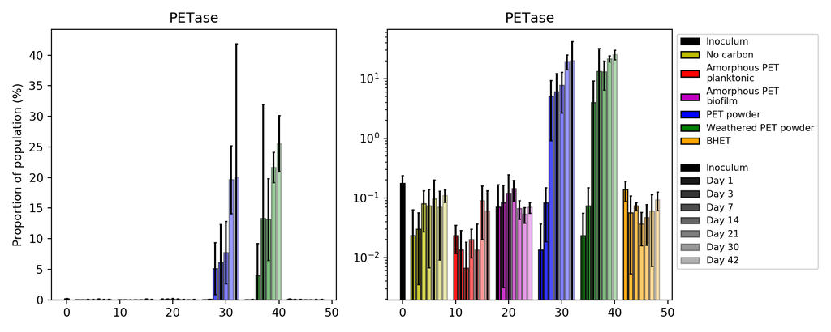

```python
plot_picrust_raw('PETase')
plt.show()
```

### tphA2

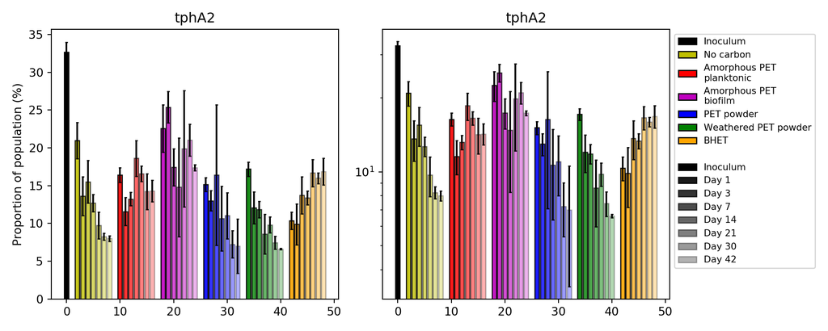

```python
plot_picrust_raw('tphA2')
plt.show()
```

### tphA3

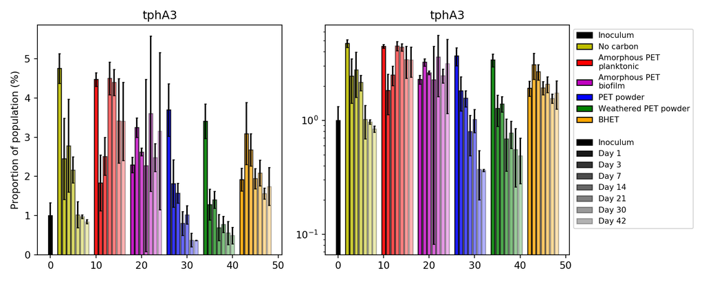

```python
plot_picrust_raw('tphA3')
plt.show()
```

### tphB

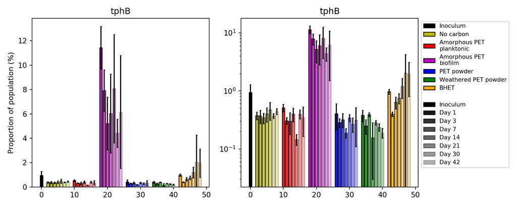

```python
plot_picrust_raw('tphB')
plt.show()
```

### K00448

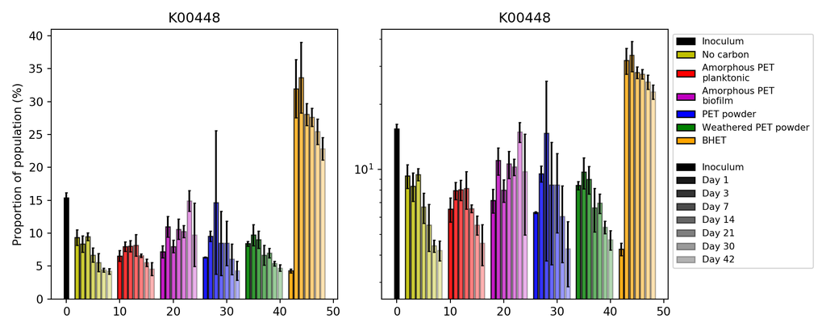

```python
plot_picrust_raw('K00448')
plt.show()
```

### K00449

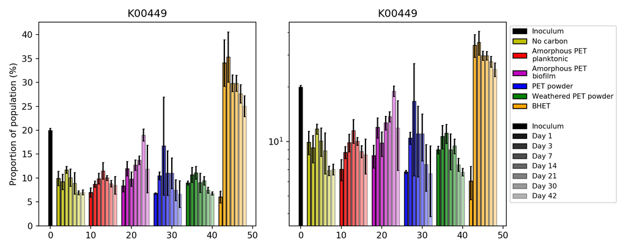

```python
plot_picrust_raw('K00449')
plt.show()
```

### K01857

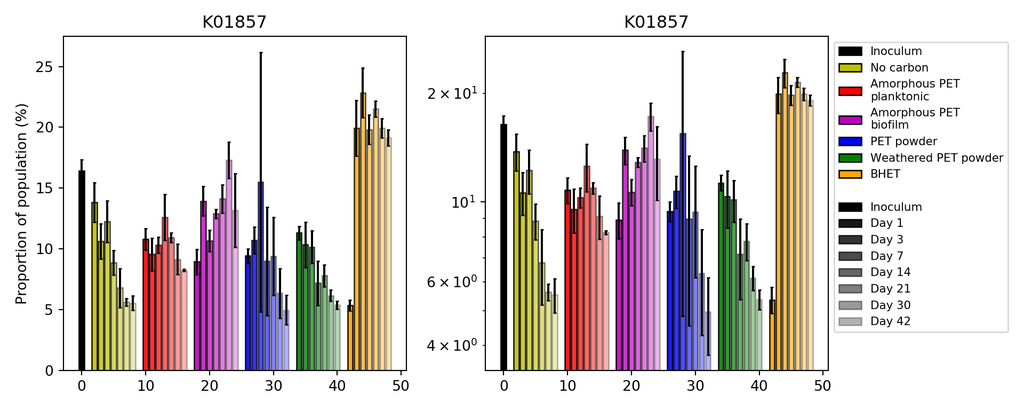

```python
plot_picrust_raw('K01857')
plt.show()
```

### K01607

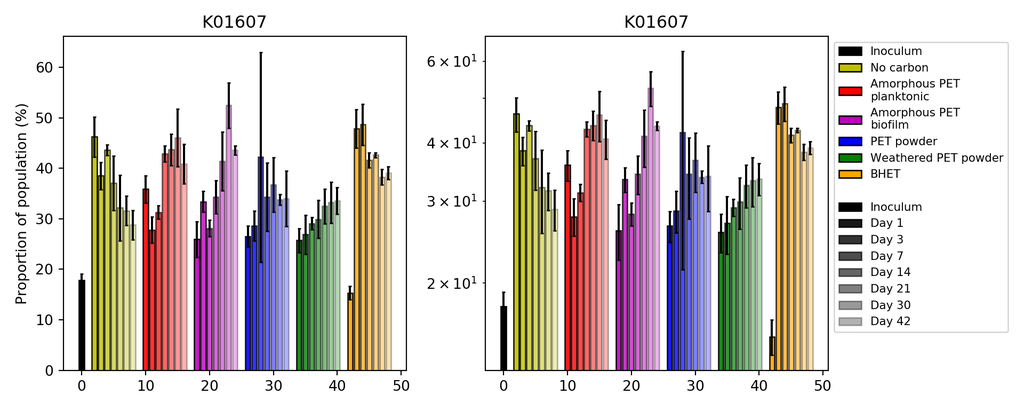

```python
plot_picrust_raw('K01607')
plt.show()
```

### K14727

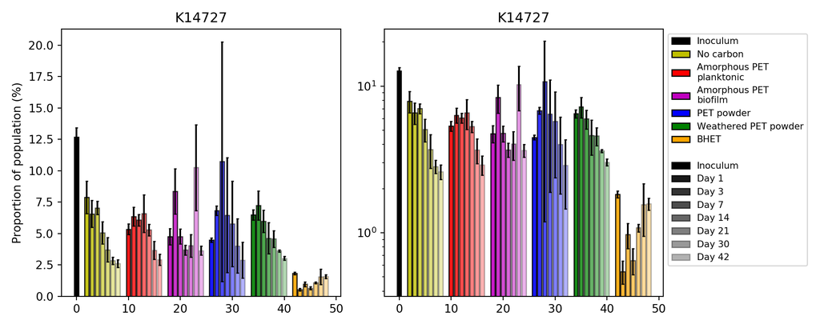

```python
plot_picrust_raw('K14727')
plt.show()
```

### K01055

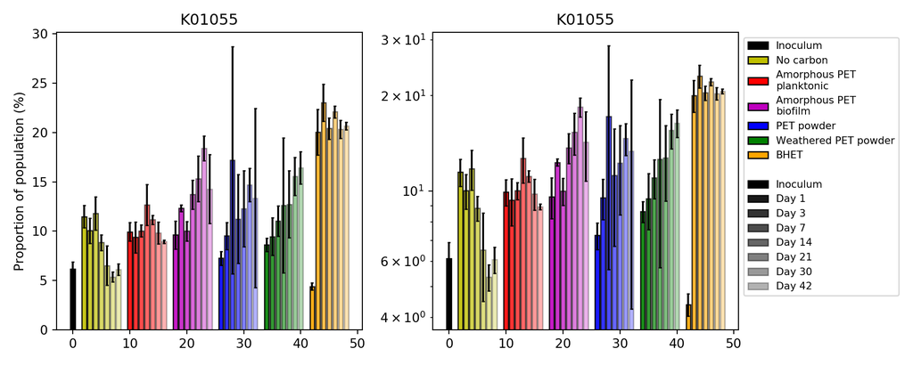

```python
plot_picrust_raw('K01055')
plt.show()
```

### K01031

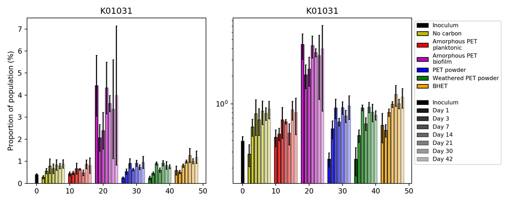

```python
plot_picrust_raw('K01031')
plt.show()
```

### K01032

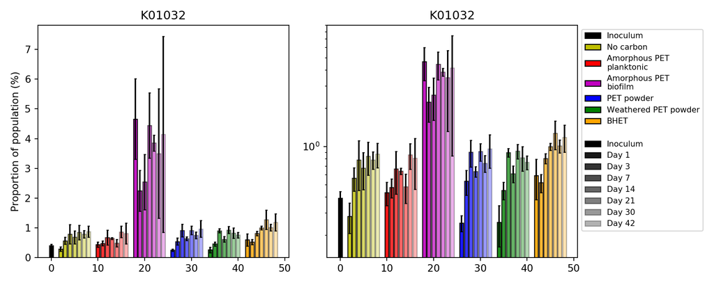

```python
plot_picrust_raw('K01032')
plt.show()
```

## Fold change with no carbon control

Now I am plotting the fold change (calculated as log2, but converted back to absolute) for each K0 compared with the mean value for the no carbon control (i.e. the mean of all replicates for all days) .

```python
picrust_unstrat_log = picrust_unstrat.replace(to_replace=0, value=0.00001)
#math.log2(num)
rename = {}
for col in list(picrust_unstrat.columns):
  if 'NoC' in col:
    rename[col] = 'NoC'
picrust_unstrat_log.rename(columns=rename, inplace=True)
def get_fc(function):
  ma, mi = 0, 0
  this_abun = pd.DataFrame(picrust_unstrat_log.loc[function, :])
  x, y = [0, 1, 2, 3, 4, 5, 6, 7, 1, 2, 3, 4, 5, 6, 7, 1, 2, 3, 4, 5, 6, 7, 1, 2, 3, 4, 5, 6, 7, 1, 2, 3, 4, 5, 6, 7, ], [0, 4, 4, 4, 4, 4, 4, 4, 3, 3, 3, 3, 3, 3, 3, 2, 2, 2, 2, 2, 2, 2, 1, 1, 1, 1, 1, 1, 1, 0, 0, 0, 0, 0, 0, 0]
  plt.figure(figsize=(6,3))
  ax1 = plt.subplot(111)
  nc = this_abun.loc['NoC', :].mean()
  print(nc)
  nc = math.log2(nc)
  new_order = []
  for sample in sample_order:
    if 'NoC' not in sample:
      new_order.append(sample)
  colormap, norm = mpl.cm.get_cmap('RdBu_r', 256), mpl.colors.Normalize(vmin=-10, vmax=10)
  m = mpl.cm.ScalarMappable(norm=norm, cmap=colormap)
  ax1 = plt.subplot2grid((7,16), (1,1), rowspan=5, colspan=7)
  axinoc = plt.subplot2grid((7,16), (3,0))
  axcolbar = plt.subplot2grid((13,16), (0,1), colspan=7, frameon=False)
  ax2 = plt.subplot2grid((7,16), (0,8), colspan=7, frameon=False)
  plt.sca(ax2)
  plt.xticks([]), plt.yticks([])
  plt.sca(axcolbar)
  plt.xticks([]), plt.yticks([])
  for a in range(len(new_order)):
    this_mean_abs = this_abun.loc[new_order[a], :].mean()
    this_mean = math.log2(this_mean_abs)
    this_diff = math.pow(this_mean-nc, 2)
    if this_diff < 1:
      this_diff = -1/this_diff
    #print(new_order[a], float(nc), float(this_mean_abs), float(this_diff), '\n')
    color = m.to_rgba(this_diff)
    if this_diff > ma: ma = this_diff
    if this_diff < mi: mi = this_diff
    if x[a] == 0 and y[a] == 0:
      axinoc.bar([1], [1], color=color, edgecolor='k', width=1)
      axinoc.set_xlim([0.5, 1.5]), axinoc.set_ylim([0,1])
      print(new_order[a])
    else:
      ax1.bar([x[a]], [1], bottom=[y[a]], color=color, edgecolor='k', width=1)
  print(new_order)
  plt.sca(ax1)
  plt.xticks([1, 2, 3, 4, 5, 6, 7], ['1', '3', '7', '14', '21', '30', '42'])
  plt.xlabel('Day')
  plt.yticks([0.5, 1.5, 2.5, 3.5, 4.5, 5.5], ['BHET', 'Weathered\nPET powder', 'PET powder', 'Amorphous PET\nBiofilm', 'Amorphous PET\nPlanktonic'])
  ax1.yaxis.set_ticks_position('right')
  plt.sca(axinoc)
  plt.xticks([1], ['Inoculum'], rotation=90)
  plt.yticks([])
  ax1.set_xlim([0.5, 7.5]), ax1.set_ylim([0, 5])
  cb1 = mpl.colorbar.ColorbarBase(axcolbar, cmap=colormap, norm=norm, orientation='horizontal')
  cb1.set_ticks([])
  axcolbar.text(-12, -25, '<-10')
  axcolbar.text(9, -25, '>10')
  axcolbar.text(0, 0, 'Fold change', ha='center', va='center')
  plt.tight_layout()
```

### PETase

```python
get_fc('PETase')
```

```python
plt.tight_layout()
```

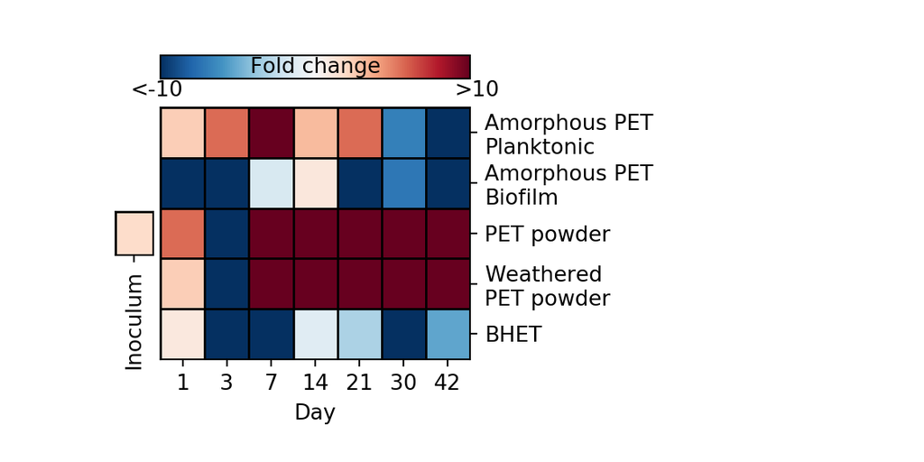

```python
plt.show()
```

### tphA2

```python
get_fc('tphA2')
```

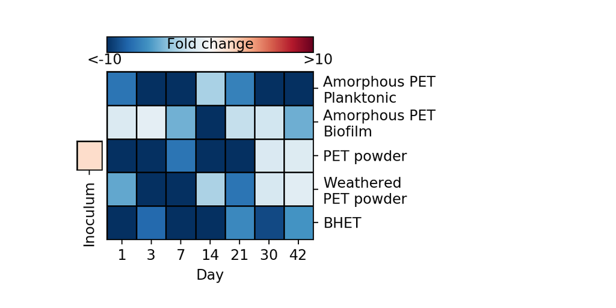

```python
plt.tight_layout()
plt.show()
```

### tphA3

```python
get_fc('tphA3')
```

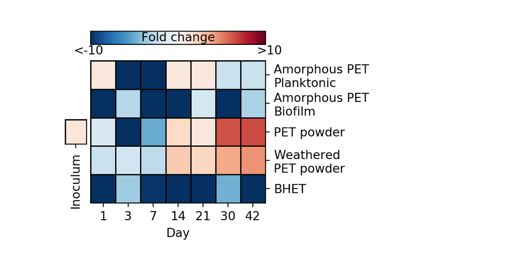

```python
plt.tight_layout()
plt.show()
```

### tphB

```python
get_fc('tphB')
```

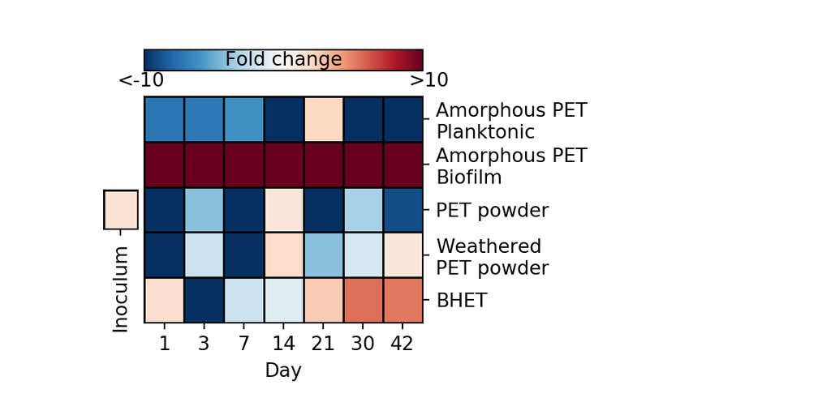

```python
plt.tight_layout()
plt.show()
```

### K00448

```python
get_fc('K00448')
```

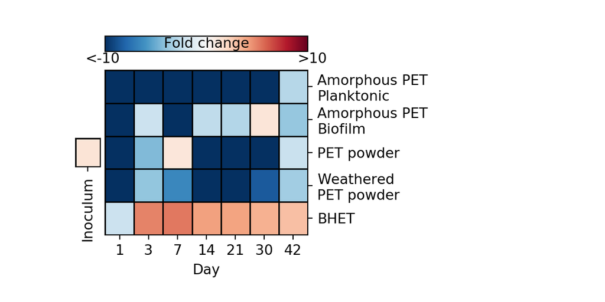

```python
plt.tight_layout()
plt.show()
```

### K00449

```python
get_fc('K00449')
```

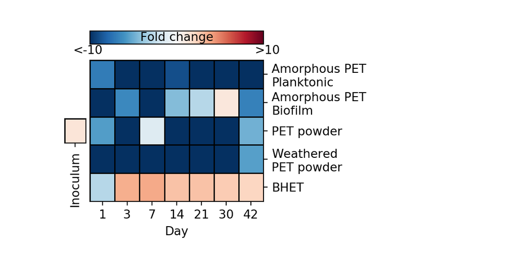

```python
plt.tight_layout()
plt.show()
```

### K01857

```python
get_fc('K01857')
```

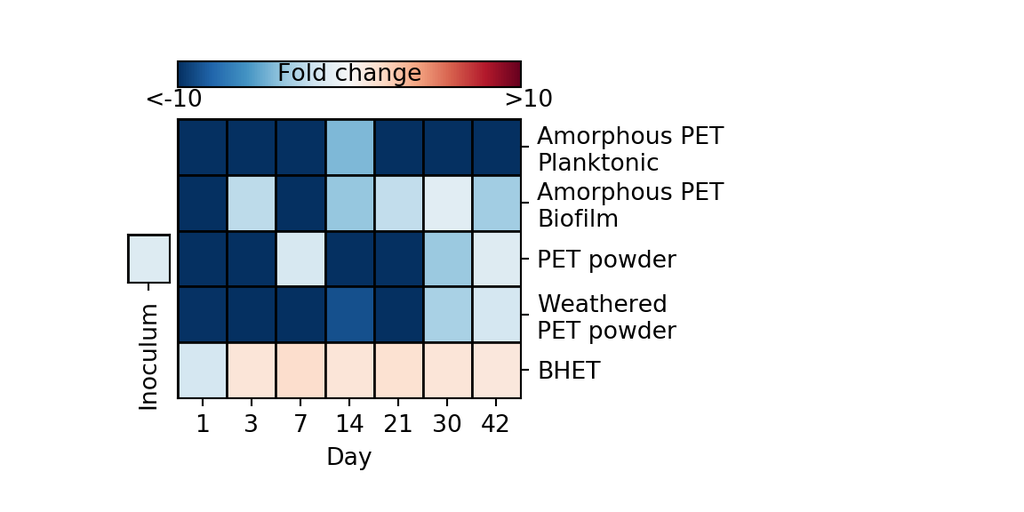

```python
plt.tight_layout()
plt.show()
```

### K01607

```python
get_fc('K01607')
```

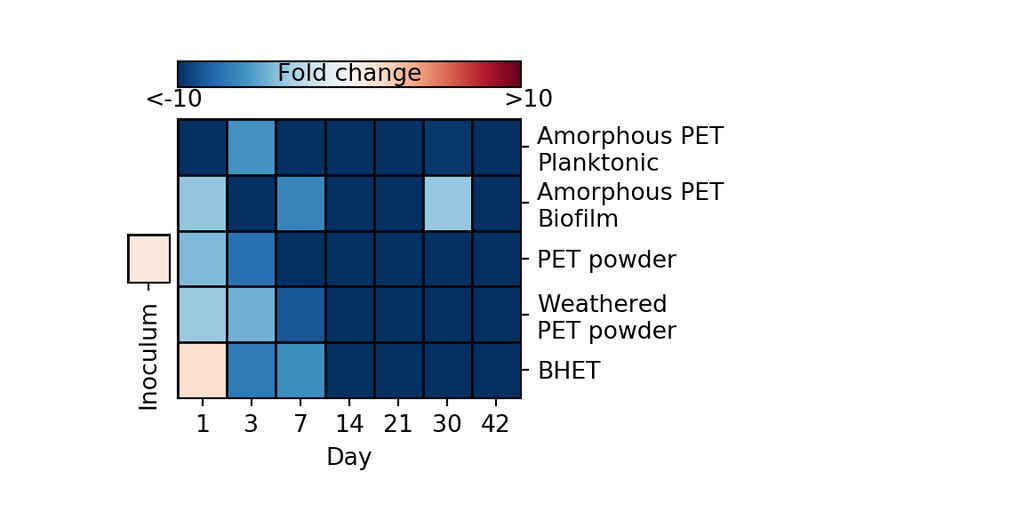

```python
plt.tight_layout()
plt.show()
```

### K14727

```python
get_fc('K14727')
```

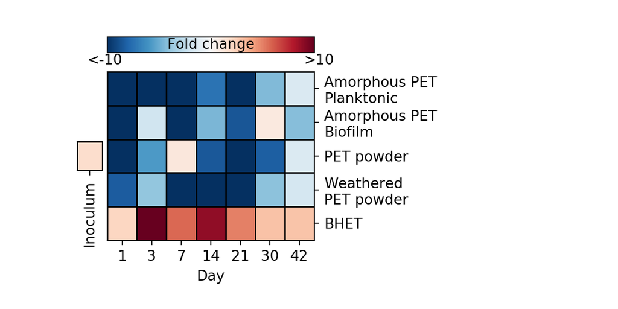

```python
plt.tight_layout()
plt.show()
```

### K01055

```python
get_fc('K01055')
```

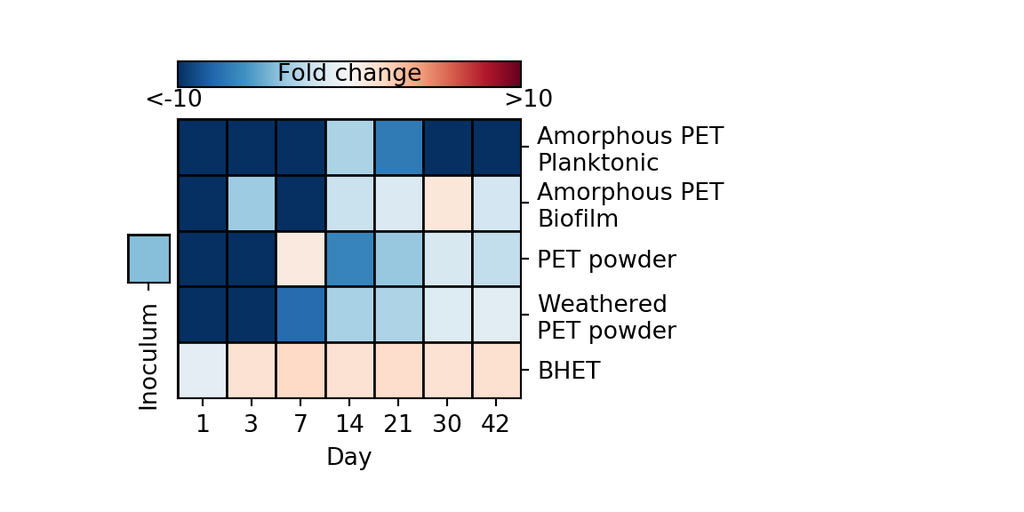

```python
plt.tight_layout()
plt.show()
```

### K01031

```python
get_fc('K01031')
```

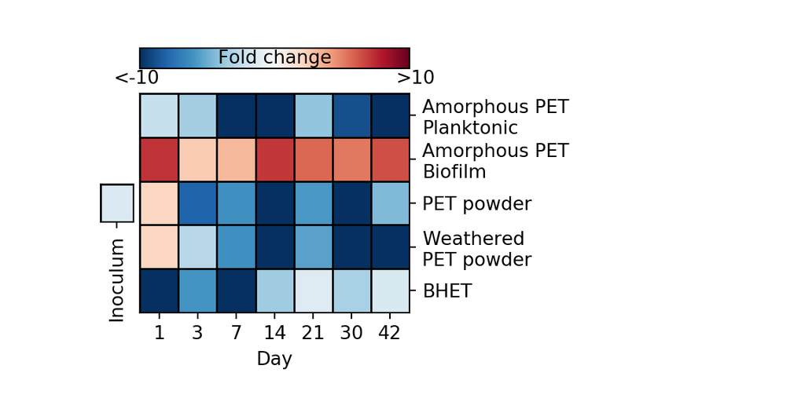

```python
plt.tight_layout()
plt.show()
```

### K01032

```python
get_fc('K01032')
```

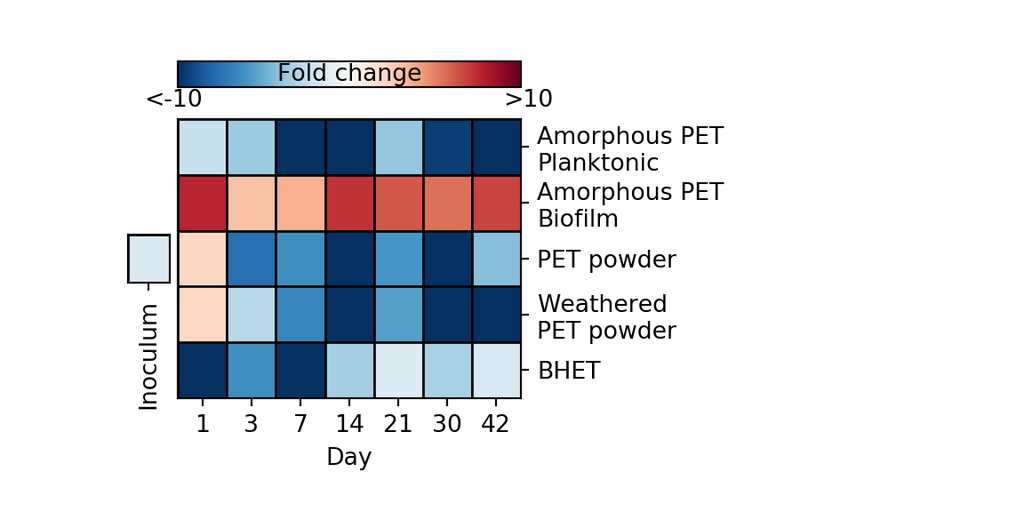

```python
plt.tight_layout()
plt.show()
```

## Contributions to key functions split by taxa

This first section is to filter the file very large (> 7 GB) default stratified PICRUSt2 output to only include the functions that we are interested in: PETase, tphA2, tphA3, tphB, K00448 and K00449. Note that for each of these, if the contributions of individual taxa were below 0.5% relative abundance, these have been grouped to ‘Other’. Taxonomic classifications shown are the lowest available for each. More than one bar for a taxonomic classification (e.g. as can be seen in K00448/K00449 for Thalassospira) indicates that more than one ASV is contributing to this genera.

```python
key_functions = ['PETase', 'tphA2', 'tphA3', 'tphB', 'K00448', 'K00449']
functions = [[], [], [], [], [], []]
count = 0
with open('/Users/robynwright/Documents/OneDrive/Github/PET-plastisphere-community/PICRUSt2/results/picrust_not_reduced/ko_all_metagenome_out/pred_metagenome_contrib.tsv') as f:
    for row in f:
        for fu in range(len(key_functions)):
            if key_functions[fu] in row:
                functions[fu].append(row)
cols = ['sample', 'function', 'taxon', 'taxon_abun', 'taxon_rel_abun', 'genome_function_count', 'taxon_function_abun', 'taxon_rel_function_abun']
count = 0
for func in functions:
    this_func = []
    for l in func:
        l = l.split('\t')
        for a in range(len(l)):
          l[a] = l[a].replace('\n', '')
        this_func.append(l)
    this_df = pd.DataFrame(this_func, columns=cols)
    this_df.to_csv('/Users/robynwright/Documents/OneDrive/Github/PET-plastisphere-community/PICRUSt2/results/picrust_not_reduced/ko_all_metagenome_out/'+key_functions[count]+'.csv')
    count += 1
```

```python
taxonomy = pd.read_csv('/Users/robynwright/Documents/OneDrive/PhD_Plastic_Oceans/Experiments/PET_MiSeq2/basic/Taxonomy.csv', header=0, index_col=0)
asvs = list(taxonomy.index.values)
labels = ['Kingdom', 'Phylum', 'Class', 'Order', 'Family', 'Genus', 'Species']
tax_dict = {}

for asv in asvs:
  this_asv = taxonomy.loc[asv, :].values
  new = ''
  for b in range(len(this_asv)):
    if not isinstance(this_asv[b], str):
      new = this_asv[b-1]
    elif b == 6 and isinstance(this_asv[b], str):
      new = this_asv[b-1]+' '+this_asv[b]
    if new != '':
      this_asv[b] = new
  tax_dict[asv] = this_asv
```

```python
key_functions = ['PETase', 'tphA2', 'tphA3', 'tphB', 'K00448', 'K00449']
sample_order = ['Day00Inoc', 'Day01NoC', 'Day03NoC', 'Day07NoC', 'Day14NoC', 'Day21NoC', 'Day30NoC', 'Day42NoC', 'Day01LowCrysWater', 'Day03LowCrysWater', 'Day07LowCrysWater', 'Day14LowCrysWater', 'Day21LowCrysWater', 'Day30LowCrysWater', 'Day42LowCrysWater', 'Day01LowCrys', 'Day03LowCrys', 'Day07LowCrys', 'Day14LowCrys', 'Day21LowCrys', 'Day30LowCrys', 'Day42LowCrys', 'Day01PET', 'Day03PET', 'Day07PET', 'Day14PET', 'Day21PET', 'Day30PET', 'Day42PET', 'Day01WeatherPET', 'Day03WeatherPET', 'Day07WeatherPET', 'Day14WeatherPET', 'Day21WeatherPET', 'Day30WeatherPET', 'Day42WeatherPET', 'Day01BHET', 'Day03BHET', 'Day07BHET', 'Day14BHET', 'Day21BHET', 'Day30BHET', 'Day42BHET']
x = [0, 2, 3, 4, 5, 6, 7, 8, 10, 11, 12, 13, 14, 15, 16, 18, 19, 20, 21, 22, 23, 24, 26, 27, 28, 29, 30, 31, 32, 34, 35, 36, 37, 38, 39, 40, 42, 43, 44, 45, 46, 47, 48]
def get_picrust_stratified_plot(function):
  plt.close()
  this_func = pd.read_csv('/Users/robynwright/Documents/OneDrive/Github/PET-plastisphere-community/PICRUSt2/results/picrust_not_reduced/ko_all_metagenome_out/'+function+'.csv', header=0, index_col=1)
  this_func.drop(['Unnamed: 0', 'function', 'taxon_abun', 'taxon_rel_abun', 'genome_function_count', 'taxon_rel_function_abun'], axis=1, inplace=True)
  rename = {}
  all_samples = list(this_func.index.values)
  for samp in all_samples:
    for sam in sample_order:
      if sam == samp[:-1]:
        rename[samp] = sam
      elif 'Inoc' in samp:
        rename[samp] = 'Day00Inoc'
  this_func = this_func.rename(index=rename)
  plotting, all_asvs = [], []
  for sam in sample_order:
    this_sample = pd.DataFrame(this_func.loc[sam, :])
    mi = 0.5
    if this_sample.shape[1] == 1:
      this_sample = this_sample.transpose()
    try:
      this_sample.set_index('taxon', inplace=True)
      if this_sample.shape[0] == 1:
        this_sample_above = this_sample
      else:
        this_sample = this_sample.groupby(by=this_sample.index, axis=0).mean()
        if this_sample.loc[:, 'taxon_function_abun'].sum() < 0.5:
          mi = 0.05
        this_sample_below = this_sample[this_sample['taxon_function_abun'] < 0.5]
        this_sample_above = this_sample[this_sample['taxon_function_abun'] >= 0.5]
        s_below = this_sample_below.loc[:, 'taxon_function_abun'].sum()
        this_sample_above.loc['Other'] = s_below
    except:
      print('Had an except')
      print(this_sample)
    plotting.append(this_sample_above)
    all_asvs += list(this_sample_above.index.values)
  genera, orders = [], []
  for asv in all_asvs:
    if asv == 'Other':
      genera.append('Other')
      orders.append('Other')
      continue
    genera.append(tax_dict[asv][-1])
    orders.append(tax_dict[asv][2])
  genera = sorted(list(set(genera)))
  colors = get_cols(len(genera))
  color_dict = {}
  handles = []
  for a in range(len(genera)):
    color_dict[genera[a]] = colors[a]
    handles.append(Patch(facecolor=colors[a], edgecolor='k', label=genera[a]))
  asv_col = {}
  for asv in all_asvs:
    if asv == 'Other':
      asv_col[asv] = color_dict['Other']
    else:
      asv_col[asv] = color_dict[tax_dict[asv][-1]]
  plt.figure(figsize=(10,4))
  ax1 = plt.subplot(111)
  for a in range(len(plotting)):
    this_plot = plotting[a]
    asvs = list(this_plot.index.values)
    bottom = 0
    for asv in asvs:
      this_num = this_plot.loc[asv, 'taxon_function_abun']
      ax1.bar(x[a], this_num, bottom=bottom, width=0.8, color=asv_col[asv], edgecolor='k')
      bottom += this_num
  fs = 10
  if len(handles) > 10:
    fs = 8
  cols = max([1, math.floor(len(handles)/10)])
  ax1.legend(handles=handles, loc='upper left', bbox_to_anchor=(1,1), ncol=cols, fontsize=fs)
  ymax = ax1.get_ylim()[1]/10
  labels = [1, 3, 7, 14, 21, 30, 42, 1, 3, 7, 14, 21, 30, 42, 1, 3, 7, 14, 21, 30, 42, 1, 3, 7, 14, 21, 30, 42, 1, 3, 7, 14, 21, 30, 42, 1, 3, 7, 14, 21, 30, 42]
  labels = [str(a) for a in labels]
  trt_labels, x_trt = ['No carbon', '\nplanktonic', '\nbiofilm', 'PET powder', 'Weathered\nPET powder', 'BHET', 'Amorphous PET'], [5, 13, 21, 29, 37, 45, 17]
  for a in range(len(trt_labels)):
    ax1.text(x_trt[a], -ymax, trt_labels[a], ha='center', va='top')
  plt.xticks(x[1:], labels, fontsize=8)
  plt.xlim([-1, 49])
  ax1.text(0, -0.5, 'Inoculum', ha='center', va='top', rotation=90)
  plt.ylabel('Relative abundance (%)')
  plt.title(function)
  plt.tight_layout()
```

### PETase

```python
get_picrust_stratified_plot('PETase')
```

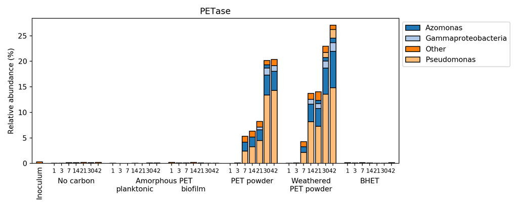

```python
plt.show()
```

### tphA2

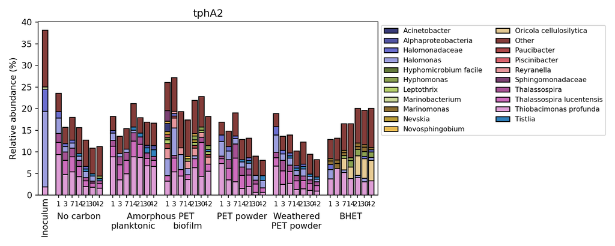

```python
get_picrust_stratified_plot('tphA2')
plt.show()
```

### tphA3

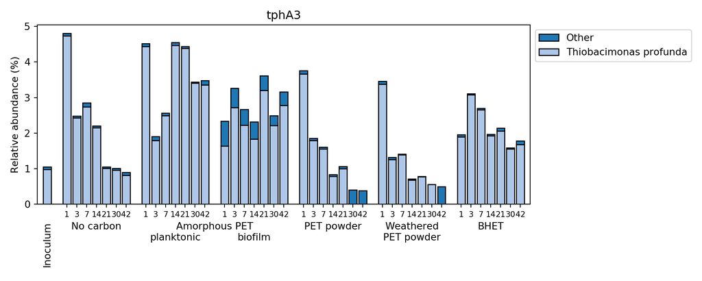

```python
get_picrust_stratified_plot('tphA3')
plt.show()
```

### tphB

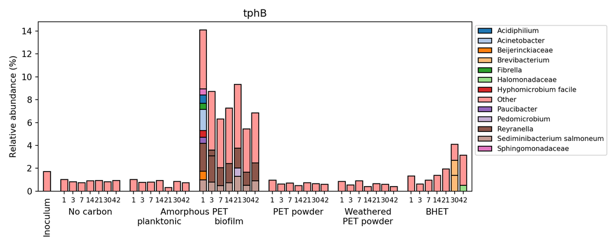

```python
get_picrust_stratified_plot('tphB')
plt.show()
```

### K00448

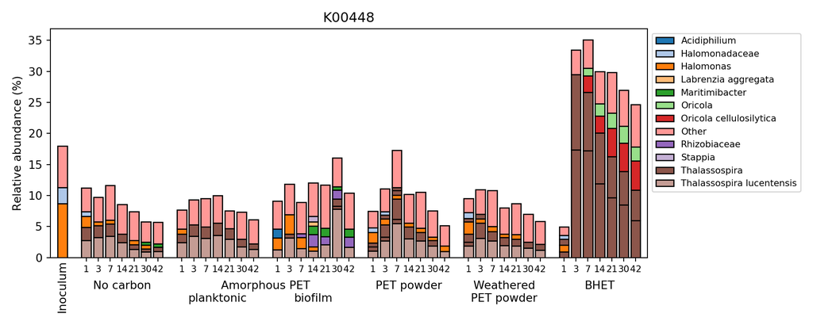

```python
get_picrust_stratified_plot('K00448')
plt.show()
```

### K00449

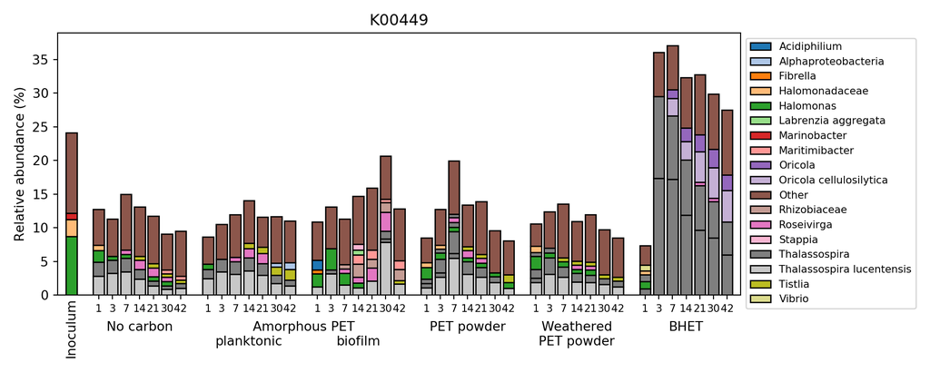

```python
get_picrust_stratified_plot('K00449')
plt.show()
```

## Oxygenases in the predicted metagenomes

```python
ko_functions = pd.read_csv('/Users/robynwright/Documents/OneDrive/Github/PET-plastisphere-community/PICRUSt2/kegg_list.csv', header=0, index_col=0)
ko = list(ko_functions.index.values)
keeping_diox, keeping_mono = [], []
for k in range(len(ko)):
  if isinstance(ko_functions.loc[ko[k], 'Product'], str):
    if 'dioxygenase' in ko_functions.loc[ko[k], 'Product']:
      keeping_diox.append(True)
    else:
      keeping_diox.append(False)
  else:
    keeping_diox.append(False)
  if isinstance(ko_functions.loc[ko[k], 'Product'], str):
    if 'monooxygenase' in ko_functions.loc[ko[k], 'Product']:
      keeping_mono.append(True)
    else:
      keeping_mono.append(False)
  else:
    keeping_mono.append(False)
dioxygenase = ko_functions.loc[keeping_diox, :]
monooxygenase = ko_functions.loc[keeping_mono, :]
print(dioxygenase, monooxygenase)
```

### Dioxygenases

The dioxygenases plotted here are just a sum of all di/mono-oxygenase genes in all community members. I’ve highlighted 100% as this would be equivalent to each bacterium having 1 gene copy, but obviously they are likely less spread.

```python
handles = []
x = [0, 2, 3, 4, 5, 6, 7, 8, 10, 11, 12, 13, 14, 15, 16, 18, 19, 20, 21, 22, 23, 24, 26, 27, 28, 29, 30, 31, 32, 34, 35, 36, 37, 38, 39, 40, 42, 43, 44, 45, 46, 47, 48]
alpha = [1, 0.9, 0.8, 0.7, 0.6, 0.5, 0.4, 0.3, 0.9, 0.8, 0.7, 0.6, 0.5, 0.4, 0.3, 0.9, 0.8, 0.7, 0.6, 0.5, 0.4, 0.3, 0.9, 0.8, 0.7, 0.6, 0.5, 0.4, 0.3, 0.9, 0.8, 0.7, 0.6, 0.5, 0.4, 0.3, 0.9, 0.8, 0.7, 0.6, 0.5, 0.4, 0.3]
for c in range(len(colors)):
  handles.append(Patch(facecolor=colors[c], edgecolor='k', label=labels[c]))
day, alph = ['Inoculum', 'Day 1', 'Day 3', 'Day 7', 'Day 14', 'Day 21', 'Day 30', 'Day 42'], [1, 0.9, 0.8, 0.7, 0.6, 0.5, 0.4, 0.3]
handles.append(Patch(facecolor='w', edgecolor='w', label=''))
for d in range(len(day)):
  handles.append(Patch(facecolor='k', edgecolor='k', label=day[d], alpha=alph[d]))

def oxygenase_plot(ko, picrust, title):
  picrust_using = pd.DataFrame(picrust)
  picrust_ko = list(picrust_using.index.values)
  ko_new, rename = [], {}
  for k in ko:
    if k in picrust_ko:
      ko_new.append(k)
      rename[k] = 'Oxygenase'
  picrust_using = pd.DataFrame(picrust_using.loc[ko_new, :])
  picrust_using = picrust_using.rename(index=rename)
  picrust_using = picrust_using.groupby(by=picrust_using.index, axis=0).sum()

  plt.figure(figsize=(10,4))
  ax1 = plt.subplot(111)
  ax1.plot([x[0], x[-1]], [100,100], 'k--')
  count = 0
  for sample in sample_order:
    mean = picrust_using.loc['Oxygenase', sample].mean()
    std = picrust_using.loc['Oxygenase', sample].std()
    for a in range(len(trts)):
      if trts[a] in sample:
        if 'Water' in sample and 'Water' not in trts[a]:
          continue
        color, label = colors[a], labels[a]
    ax1.bar(x[count], mean, yerr=std, color=color, edgecolor='k', alpha=alpha[count], capsize=1)
    count += 1
  ax1.legend(handles=handles, loc='upper left', bbox_to_anchor=(1,1), fontsize=8)
  ax1.set_title(title)
  ax1.set_ylabel('Proportion of population (%)')
  plt.sca(ax1)
  plt.ylim(ymin=0)
  plt.xlim([-1, 49])
  plt.tight_layout()
  return

cols = list(picrust_unstrat_all.columns)
rename = {}
dropping = []
for col in cols:
  for sam in sample_order:
    if sam == col[:-1]:
      rename[col] = sam
    elif 'Inoc' in col:
      rename[col] = 'Day00Inoc'
  if 'Control' in col:
    dropping.append(col)
picrust_unstrat_all = picrust_unstrat_all.rename(columns=rename)
picrust_unstrat_all = picrust_unstrat_all.drop(dropping, axis=1)
```

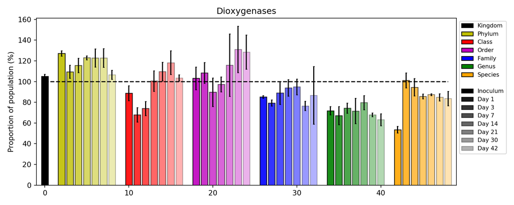

```python
oxygenase_plot(list(dioxygenase.index.values), picrust_unstrat_all, 'Dioxygenases')
plt.show()
```

### Monooxygenases

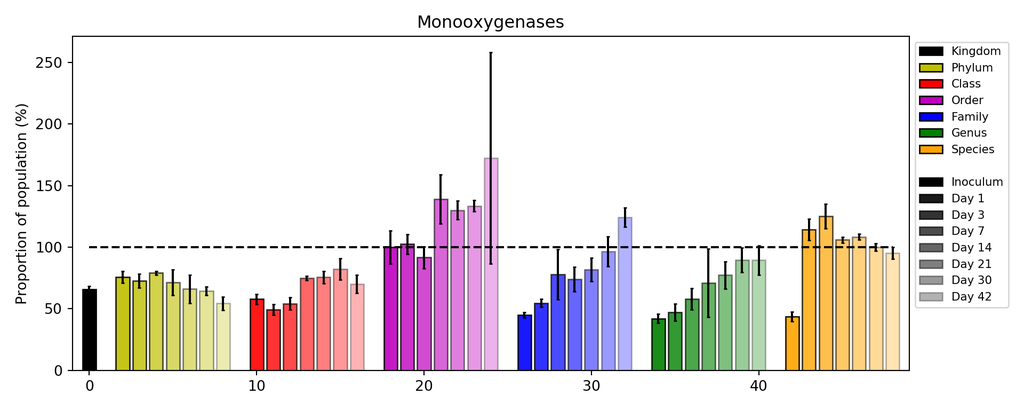

```python
oxygenase_plot(list(monooxygenase.index.values), picrust_unstrat_all, 'Monooxygenases')
plt.show()
```